# COVID-19 US Weekly Forecast Summary

[The COVID-19 Forecast Hub Team](https://covid19forecasthub.org/doc/) https://covid19forecasthub.org/

report generated 2023-08-29

# Background

This report provides a brief summary of the weekly ensemble forecast from the [COVID-19 Forecast Hub](https://covid19forecasthub.org/) based on forecasts submitted on August 28, 2023. In collaboration with the US CDC, our team aggregates COVID-19 forecasts from dozens of teams around the globe. Typically on Wednesday of each week, a summary of the week's forecasts from the COVID-19 Forecast Hub appear on the [official CDC COVID-19 forecasting page](https://www.cdc.gov/coronavirus/2019-ncov/covid-data/forecasting-us.html).

Every week, teams submit their forecasts to the COVID-19 Forecast Hub. This past week, 10 models were submitted.

Each Tuesday, we combine the most recent forecasts from each team into a single "ensemble" forecast of reported COVID-19 hospitalizations at the state and national level. As of February 20, 2023, we are no longer working with case forecasts, and as of March 6, 2023, we are no longer generating ensemble death forecasts. Older reports include case and death forecasts. At the moment, we only generate ensemble forecasts for up to four weeks into the future, as [the available evidence](https://www.pnas.org/doi/full/10.1073/pnas.2113561119) suggests that models are less accurate at longer forecast horizons.

An archive of weekly reports from the COVID-19 Forecast Hub can be found at [this page](https://covid19forecasthub.org/doc/reports/).

# COVID-19 Forecasts

## National level

This week, our ensemble combined forecasts from 10 different models.

As of September 28, 2021 the ensemble forecast only reports 14 day ahead forecasts for hospitalizations, due to persistent large inaccuracies observed when forecasting beyond that.

For September 11, 2023 COVID-19 daily hospitalizations in the US will be between 1,200 and 6,300 (95% prediction interval: 1,200 - 6,260).

You can explore the full set of models, including their forecasts for past weeks online at the [Forecast Hub interactive visualization](https://viz.covid19forecasthub.org/).

### Hospitalizations

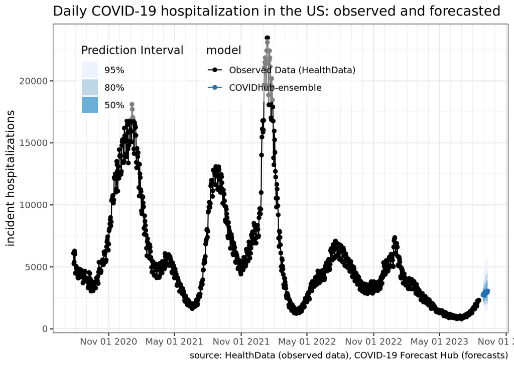

# Methods & Acknowledgement

This report was reproducibly and dynamically generated using RMarkdown. The code for the report can be found [here](https://github.com/reichlab/covid19-forecast-hub/tree/master/code/reports).